# Introduction

Eunseo Yoon

2022-06-17

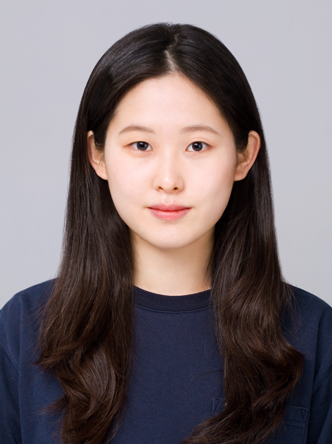

## Profile

- 만 21세
- 성동구 마장동 거주
- 한양대학교 데이터사이언스학과 3학년 재학 – 2년 과대표 연임으로 데사학부 1짱자리 확보
- 2022-1학기 창업실무:고객데이터분석및활용기초 수강

## To visitors

교수님 안녕하세요^^ 이 페이지에 visitor는 현열교수님뿐이기에 기회삼아 짧은 쪽지를 남겨봅니다.

교수님 한학기동안 수업 잘 들었습니다. 처음 개설된 강의라 수강신청 떄 잠시 고민을 했지만, 교수님의 첫번째 학생이 될 수 있어서 큰 영광입니다!! 에타 강의평가에 이 수업을 추천하는 장문의 글을 올릴 생각에 두근두근합니다:) (사실 이모티콘을 사용하고 싶지만, 방법을 모르고 찾을 열쩡이 없습니다,,,><)

사실 수업 내용보다도 교수님처럼 열심히 살아야겠다는 자극을 많이 받았습니다. 현재 종강을 앞두고 신나게 놀 계획밖에 세우지 못했지만, 이번 여름방학에는 갓생을 살겠다고 다짐해봅니다!!

교수님 한학기동안 수고 많으셨습니다. 감사합니다~!